# Time to Reincarceration in Iowa:

A Cox Proportional Hazards Analysis

Author

Aliyah Hunter & Sophia Bamman Craig (Advisor: Dr. Cohen)

Published

October 26, 2026

Slides: slides.html ( Go to `slides.qmd` to edit)

## Introduction

In many studies, the outcome of interest is not only whether an event occurs, but also how long it takes for that event to happen. For example, researchers may be interested in how long a patient survives after treatment, when a borrower defaults on a loan, or when a user leaves a website. Survival analysis considers both whether an event occurs and the time until it occurs, while accounting for censored observations.

The Cox proportional hazards model is one of the most commonly used methods for analyzing time-to-event data. The model allows researchers to examine how different variables are related to the risk of experiencing an event over time. Because of this, Cox regression can be applied to many different types of research questions. Previous studies have used Cox models to examine the duration of the birth process (Wuryandari et al. 2018), the time until farmers are willing to pay agricultural insurance premiums (Hidayat et al. 2022), website drop-offs (Soobramoney et al. 2023), credit default (Dirick et al. 2017), and survival following cancer treatments (Abadi et al. 2014). Although these studies focus on very different outcomes, they all use the same general idea of examining the time until a specific event occurs.

An important part of using the Cox model is the proportional hazards assumption. This assumption means that the effect of a predictor on the hazard is expected to remain proportional over time. For example, if one group has a higher risk of experiencing an event than another group, the model assumes that the relative difference between those groups remains consistent throughout the study period. If that relationship changes over time, a single hazard ratio may not accurately describe the effect of the predictor.

### Literature Review

#### Cox PH model across domains

Empirical studies have shown that the Cox PH model can be used well beyond its origin in clinical survival analysis. The studies reviewed for this project applied the model to academic performance, childbirth, agricultural economics, website use, and credit risk. Thus, the model could be used in any setting that has time-to-event data with censoring. In a study on medical student attrition, a stepwise Cox model was used to examine which academic and demographic factors predicted when a student would experience academic difficulty. Researchers found that curriculum track, MCAT verbal reasoning scores, and early course failures were the strongest predictors, and that the risk peaked at a specific point in the training timeline (Chau-Kuang 2010). In a study on the duration of childbirth, Cox PH was used to examine whether a specific birth-preparation method changed the time it took to deliver. The study found that this method significantly shortened the time to delivery compared to standard practice (Wuryandari et al. 2018). (Hidayat et al. 2022) applied Cox PH to model economic behavior, using the Efron partial-likelihood method and stepwise variable selection to examine how long it took rice farmers to pay an agricultural insurance premium. They found that education level, off-farm employment, and production costs affected how quickly farmers acted.(Soobramoney et al. 2023) treated website user drop-off as a survival problem, in which “survival” meant viewing at least three pages. Both Cox PH and a survival random forest model were used, and browser type, landing page, and search-referral status were found to be key hazards. This shows that the framework is not limited to health and social science, and it can be applied to behavioral and business data as well. Together, these studies show that all the model needs is a duration variable and a binary event or censoring indicator. Also, the Cox model can flexiby handle multiple covariates. Therefore, it is a tool that could be useful wherever the timing of an outcome is of interest. For these reasons, Cox PH was chosen for the recidivism data in this study, which has this same time-to-event structure.

#### Proportional hazards assumption

Another theme in the literature is that researchers should test that a covariate’s effect on hazard stays constant over time. (Bellera et al. 2010) warned that predictors can look strong early in follow-up and then weaken considerably over time. Using Schoenfeld residuals, they showed that hormone receptor status in breast cancer patients had this kind of time-varying effect. A standard Cox model would have hidden this finding. (Abadi et al. 2014) reached a similar conclusion in a separate and larger breast cancer survival study. They found that the proportional hazards assumption held differently across age and cancer-stage subgroups and fitting stratified Cox models to account for this difference between the groups. Also, (Lee 2023) made the same point in a more general methodological review. This review noted that hazard or survival curves that overlap on a graph are a practical sign that the PH assumption has been violated. Failing to detect a violation could lead to misleading conclusions about the true relationship between a covariate and the outcome. For recidivism data, a covariate’s effect on the hazard of reincarceration could be concentrated in the early months, therefore the proportional hazards assumption will be tested.

#### Handling non-proportional hazards

Several reviewed studies compared modified Cox specifications designed to address PH violations. (Iketle et al. 2024) compared the stratified Cox model, which allows a different baseline hazard for each level of a violating covariate, against the extended Cox model, which puts time-varying covariates directly into the hazard function. This was done using Monte Carlo simulations across different censoring rates, sample sizes, and survival distributions. They found that the extended model performed better than the stratified model when a true time-varying effect was present. However, they noted that there were practical limitations in specifying the correct functional form for that time dependence. (M. S. K and Murugan 2024) emphasized that the Cox model’s main value was that it could isolate each covariate’s independent contribution to hazard while controlling for the others. However, they cautioned that the PH assumption itself, along with the interpretation of complex covariate interactions, remained a limitations of this approach. (Dirick et al. 2017) took this comparative approach even further in a credit-risk context. They benchmarked Cox PH against accelerated failure time models, spline-based Cox extensions, and mixture cure models (designed to account for a subpopulation that will never experience the event at all) across ten datasets. This study found that Cox PH with penalized splines consistently outperformed fully parametric alternatives, reinforcing the model’s flexibility even when covariate-hazard relationships are nonlinear.

Overall, the Cox PH is well suited to the structure of the Iowa data. This study will begin with a standard Cox PH model, tests the proportional hazards assumption formally using Schoenfeld residuals, and addresses any violations dectected through stratification or time-varying covariate specifications.

## Methods

### Cox Proportional Hazards Model

Survival analysis examines both whether an event occurs and the amount of time before it occurs, while accounting for censored observations. An observation is right-censored when the event has not been observed by the end of the available follow-up. The Cox proportional hazards model evaluates associations between explanatory variables and the hazard of an event. In this analysis, the event of interest was reincarceration.

The Cox model expresses an individual’s hazard at time (t) as

$$\lambda(t \mid X) = \lambda_0(t)\exp(\beta_1X_1+\beta_2X_2+\cdots+\beta_pX_p),$$

where (_0(t)) is the baseline hazard, (_j) represents a regression coefficient, and (X_j) represents an explanatory variable. The baseline hazard is left unspecified, allowing the model to estimate predictor associations without assuming a particular survival-time distribution (Bellera et al. 2010).

Exponentiating a coefficient produces a hazard ratio:

$$\text{HR}_j=\exp(\beta_j).$$

For a continuous predictor, this represents the relative hazard associated with a one-unit increase, holding other predictors constant. For a categorical predictor, it compares a category with its reference category. A hazard ratio greater than one indicates a higher hazard of reincarceration, while a value below one indicates a lower hazard. A value of one indicates no difference in hazard. Hazard ratios describe relative instantaneous event rates among individuals who have not yet experienced the event, rather than differences in the probability of reincarceration.

### Initial Graphical Analysis and Group Comparisons

Kaplan–Meier curves were used to describe the probability of remaining free from reincarceration over time across risk classifications, offense types, sex, and release types. This method incorporates right-censored observations without requiring proportional hazards. Curves were examined to identify differences in survival patterns and provide an initial visual assessment of potential non-proportionality.

Crossing curves or changes in their relative patterns over time may suggest that group associations vary over time. However, the absence of crossing does not establish that the proportional hazards assumption holds. Visual interpretation can also become more difficult when several categories are displayed together. Kaplan–Meier plots were therefore treated as an exploratory assessment rather than a definitive test of proportional hazards (Bellera et al. 2010).

Log-rank tests were used to compare survival distributions across offense types, sex, and release types. These tests compare observed and expected event counts across time to evaluate the null hypothesis that the groups have the same survival distribution. They assess unadjusted group differences and do not account for other predictors.

### Assessing Proportional Hazards

The Cox model assumes that hazard ratios remain constant over time. Although the baseline hazard may change over time, the relative hazard associated with a predictor is assumed to remain the same. Graphical assessment can identify possible departures from this assumption, but additional model diagnostics are needed to evaluate whether predictor effects vary over time.

One approach is to extend the Cox model by adding an interaction between a predictor and a function of time. This allows the predictor’s effect to change during follow-up. The time function may be time itself, time squared, or the logarithm of time. Testing whether the interaction coefficient differs significantly from zero provides a formal assessment of non-proportionality. A significant interaction provides evidence that the predictor’s effect changes over time. The fitted model can then estimate hazard ratios at specific time points to describe this changing association. However, the approach depends on selecting an appropriate time function; an unfit function may fail to capture the pattern of change (Bellera et al. 2010).

Another approach uses Schoenfeld residual tests and plots to assess whether estimated predictor effects change systematically over time. A roughly horizontal pattern supports a constant effect, while an organized trend may indicate non-proportionality. Statistical tests and graphical patterns should be considered together when evaluating the assumption (Bellera et al. 2010).

### Addressing Non-Proportionality

When the proportional hazards assumption is violated, the appropriate modification depends on the predictor and the research question. A stratified Cox model allows separate baseline hazards across categories of a stratification variable while estimating common effects for the remaining predictors. This approach accommodates differences in baseline hazard patterns but does not estimate a hazard ratio for the stratification variable.

## Analysis and Results

### Data Exploration and Visualization

The Iowa Prison Recidivism Status dataset contains 31,703 case-level records of individuals released from Iowa prisons through parole, work release, or discharge, beginning with the FY2016 cohort. It covers releases from July 2015 through June 2022 and tracks whether each individual was reincarcerated. Available variables include age, sex, race, the original offense, the convicting offense on recidivism if one occurred, and a risk classification.

This analysis looks at reincarceration outcomes for 31,700 individuals who were followed for up to three years after release, three cases removed due to sex and race being unknown. The overall reincarceration rate was 36.9%, but this rate varied across demographic and offense-based subgroups. Violent offenders had the lowest rate at 29.2%, while individuals convicted of “other” offenses had the highest at 50.3%. This goes against a common assumption that more severe offenses lead to worse reentry outcomes. The timing of reincarceration also showed a clear pattern. Among release records with observed reincarceration, the average time to reincarceration is 449 days, and the rate of return leveled off after that point.

Differences appeared across several other groups as well. Males were reincarcerated at a rate about 8 percentage points higher than females (38.0% vs. 30.0%). American Indian or Alaska Native individuals had the highest rate of any racial group at 44.7%. Risk classification separated outcomes as intended, with high risk individuals reincarcerated at a rate of 42.0% compared to 31.4% for low risk individuals. However, individuals who were never formally assessed had a lower rate than the low risk group. This might indicate some bias as the reason for the missing risk is unknown.

```r
# loading packages
library(tidyverse)
library(knitr)
library(ggthemes)
library(ggrepel)
library(dslabs)
library(survival)
library(survminer)
library(skimr)
library(RColorBrewer)
```

```r
# Load Data
data_raw <- read_csv("ipr_dataset.csv", na = c("", "NA"))
# Data Cleaning
empty_cols <- names(data_raw)[colSums(is.na(data_raw)) == nrow(data_raw)]
data <- data_raw %>% select(-all_of(empty_cols))

df <- data %>%
  mutate(
    event = as.integer(is_recid),
    release_date = as.Date(exit_sup_end_date),
    time_days = if_else(event == 1L, days_to_recid, 1095),                             # Assign observed event times; censor non-events at 1095 days
  )

df <- df %>% mutate(time_days = if_else(time_days == 0, 0.5, time_days))

df <- df %>%
  unite("exit_combined", exit_type, exit_subtype, sep = " - ", remove = FALSE) %>%
  filter(!is.na(sex)) %>%
  mutate(
    sex               = factor(sex),
    Race              = factor(Race),
    exit_type         = factor(exit_type),
    exit_sup_reason   = factor(exit_sup_reason),
    risk_ranking      = factor(
      if_else(is.na(risk_ranking), "Not Assessed", risk_ranking),
      levels = c("Low", "Moderate", "High", "Not Assessed")
    ),
    age_c             = age - mean(age, na.rm = TRUE)
  )
```

```r
data_raw |>
  nrow()  # 31703 original records before cleaning
```

```
[1] 31703
```

```r
data_raw |>
  filter(is.na(sex))
```

```
# A tibble: 3 × 37
  record_id offender_cd birth_date   age Race    sex   region_exit      exit_sup
  <lgl>     <lgl>       <lgl>      <dbl> <chr>   <chr> <chr>            <chr>
1 NA        NA          NA            27 Unknown <NA>  Districts/Compa… Prison
2 NA        NA          NA            27 Unknown <NA>  Districts/Compa… Prison
3 NA        NA          NA            31 Unknown <NA>  Districts/Compa… Prison
# ℹ 29 more variables: cohort_fiscal_year <dbl>, report_fiscal_year <dbl>,
#   report_fiscal_year_name <chr>, exit_sup_start_date <date>,
#   exit_sup_end_date <date>, months_supervised <dbl>, exit_sup_reason <chr>,
#   charge_id <dbl>, exit_class <chr>, exit_type <chr>, exit_subtype <chr>,
#   is_recid <lgl>, new_tech <chr>, days_to_recid <dbl>,
#   survival_time_months <dbl>, recid_convicting_crime_cd <chr>,
#   recid_convicting_crime_cd_class <chr>, recid_convicting_crime_type <chr>, …
```

```r
df |>
  nrow()  # 31700 records analyzed - 3 removed due to sex and race being NA
```

```
[1] 31700
```

```r
data_raw |>
  summarise(
    same_day_events = sum(
      is_recid == TRUE & days_to_recid == 0,
      na.rm = TRUE
    )
  )
```

```
# A tibble: 1 × 1
  same_day_events
            <int>
1               6
```

```r
df |>
  filter(event == 1, days_to_recid == 0) |>           # Six records had reincarceration recorded on the day of release; analysis times were assigned 0.5 days to represent same-day events.
  select(days_to_recid, time_days, event)
```

```
# A tibble: 6 × 3
  days_to_recid time_days event
          <dbl>     <dbl> <int>
1             0       0.5     1
2             0       0.5     1
3             0       0.5     1
4             0       0.5     1
5             0       0.5     1
6             0       0.5     1
```

```r
df |>
  filter(event == 1) |>
  summarise(mean_days = mean(time_days, na.rm = TRUE))
```

```
# A tibble: 1 × 1
  mean_days
      <dbl>
1      449.
```

```r
df |>
  summarise(
    recid_rate = mean(event, na.rm = TRUE) * 100
  )
```

```
# A tibble: 1 × 1
  recid_rate
       <dbl>
1       36.9
```

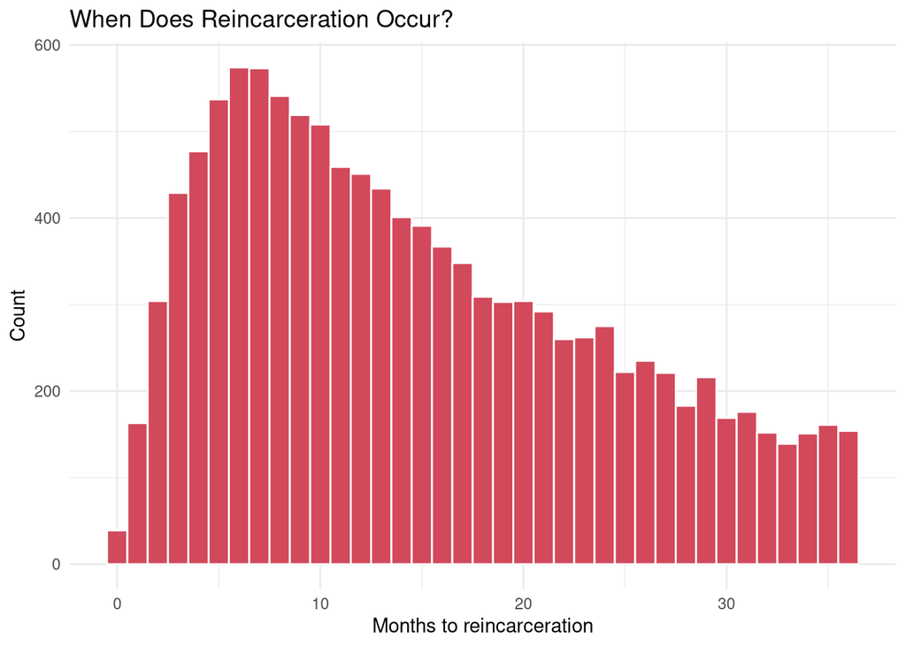

```r
df %>%
  filter(event == 1L) %>%
  ggplot(aes(x = survival_time_months)) +
  geom_histogram(binwidth = 1, fill = "#d1495b", color = "white") +
  labs(title = "When Does Reincarceration Occur?",
       x = "Months to reincarceration", y = "Count") +
  theme_minimal()
```

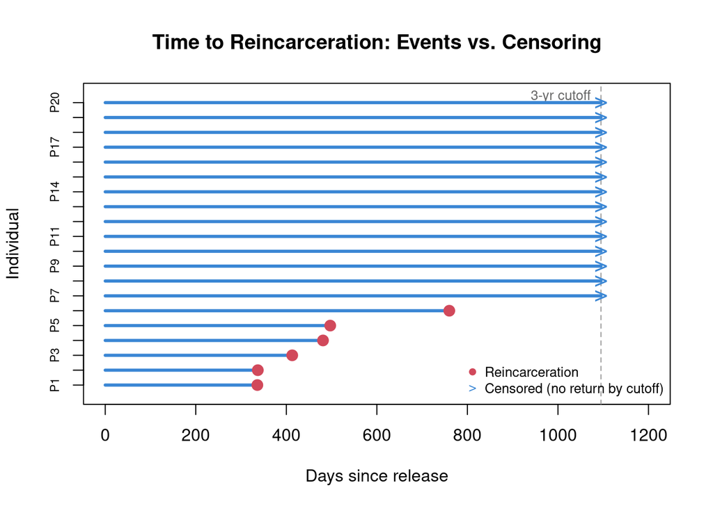

```r
set.seed(20)

pt <- df %>%
  slice_sample(n = 20) %>%
  arrange(time_days) %>%
  mutate(id = row_number())

plot(NA, xlim = c(0, 1200), ylim = c(0.5, 20.5),
     xlab = "Days since release", ylab = "Individual", yaxt = "n",
     main = "Time to Reincarceration: Events vs. Censoring")
axis(2, at = 1:20, labels = paste0("P", 1:20), cex.axis = 0.7)
abline(v = 1095, lty = 2, col = "grey60")
text(1095, 20.4, "3-yr cutoff", pos = 2, col = "grey40", cex = 0.8)

for (i in 1:20) {
  segments(0, pt$id[i], pt$time_days[i], pt$id[i], col = "#3a86d4", lwd = 3)
  if (pt$event[i] == 1) {
    points(pt$time_days[i], pt$id[i], pch = 19, col = "#d1495b", cex = 1.4)
  } else {
    points(pt$time_days[i], pt$id[i], pch = ">", col = "#3a86d4", cex = 1.4)
  }
}
legend("bottomright",
       inset = 0,
       cex = 0.8,
       bty = "n",
       legend = c("Reincarceration", "Censored (no return by cutoff)"),
       pch = c(19, 62),
       col = c("#d1495b", "#3a86d4"))
```

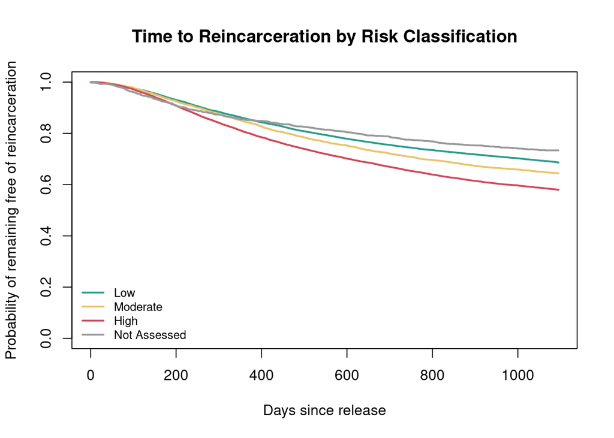

```r
km_risk <- survfit(Surv(time_days, event) ~ risk_ranking, data = df)

plot(km_risk, col = c("#2a9d8f", "#e9c46a", "#d1495b", "grey60"), lwd = 2,
     xlab = "Days since release", ylab = "Probability of remaining free of reincarceration",
     xlim = c(0, 1095), ylim = c(0, 1),
     main = "Time to Reincarceration by Risk Classification")
legend("bottomleft", bty = "n", lwd = 2,
       legend = levels(df$risk_ranking),
       cex = 0.8,
       col = c("#2a9d8f", "#e9c46a", "#d1495b", "grey60"))
```

```r
survdiff(Surv(time_days, event) ~ risk_ranking, data = df)
```

```
Call:
survdiff(formula = Surv(time_days, event) ~ risk_ranking, data = df)

                              N Observed Expected (O-E)^2/E (O-E)^2/V
risk_ranking=Low          10068     3159     3861    127.55    190.52
risk_ranking=Moderate      4776     1699     1786      4.23      4.99
risk_ranking=High         15290     6424     5446    175.77    329.17
risk_ranking=Not Assessed  1566      417      607     59.33     62.61

 Chisq= 367  on 3 degrees of freedom, p= <2e-16
```

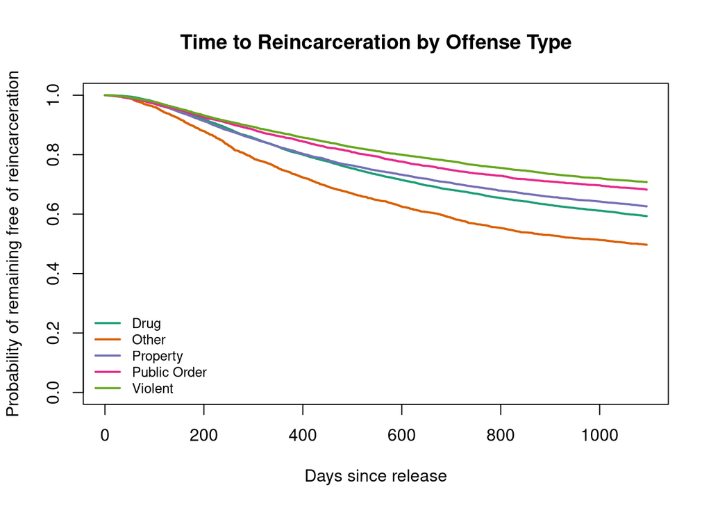

```r
km_exit <- survfit(Surv(time_days, event) ~ exit_type, data = df)

colors <- brewer.pal(8, "Dark2")
group_labels <- sub("^[^=]+=", "", names(km_exit$strata))

plot(km_exit, col = colors, lwd = 2,
     xlab = "Days since release", ylab = "Probability of remaining free of reincarceration",
     xlim = c(0, 1095), ylim = c(0, 1),
     main = "Time to Reincarceration by Offense Type")
legend("bottomleft", bty = "n", lwd = 2,
       legend = group_labels,
       cex = 0.8,
       col = colors)
```

```r
survdiff(Surv(time_days, event) ~ exit_type, data = df)
```

```
Call:
survdiff(formula = Surv(time_days, event) ~ exit_type, data = df)

                          N Observed Expected (O-E)^2/E (O-E)^2/V
exit_type=Drug         9035     3678     3272     50.46     70.09
exit_type=Other        2779     1398      915    255.58    277.52
exit_type=Property     8771     3279     3213      1.37      1.89
exit_type=Public Order 3784     1202     1446     41.04     46.85
exit_type=Violent      7331     2142     2855    177.85    235.47

 Chisq= 527  on 4 degrees of freedom, p= <2e-16
```

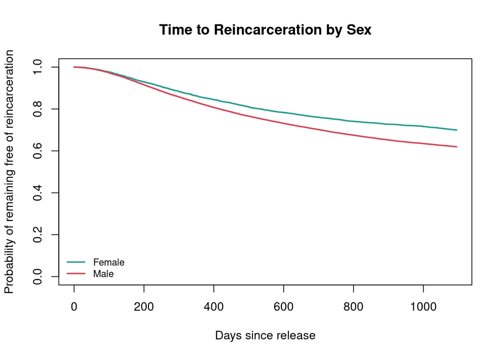

```r
km_sex <- survfit(Surv(time_days, event) ~ sex, data = df)

plot(km_sex, col = c("#2a9d8f", "#d1495b"), lwd = 2,
     xlab = "Days since release", ylab = "Probability of remaining free of reincarceration",
     xlim = c(0, 1095), ylim = c(0, 1),
     main = "Time to Reincarceration by Sex")
legend("bottomleft", bty = "n", lwd = 2,
       legend = levels(df$sex),
       cex = 0.8,
       col = c("#2a9d8f", "#d1495b"))
```

```r
survdiff(Surv(time_days, event) ~ sex, data = df)
```

```
Call:
survdiff(formula = Surv(time_days, event) ~ sex, data = df)

               N Observed Expected (O-E)^2/E (O-E)^2/V
sex=Female  4520     1358     1740      83.8      98.5
sex=Male   27180    10341     9959      14.6      98.5

 Chisq= 98.5  on 1 degrees of freedom, p= <2e-16
```

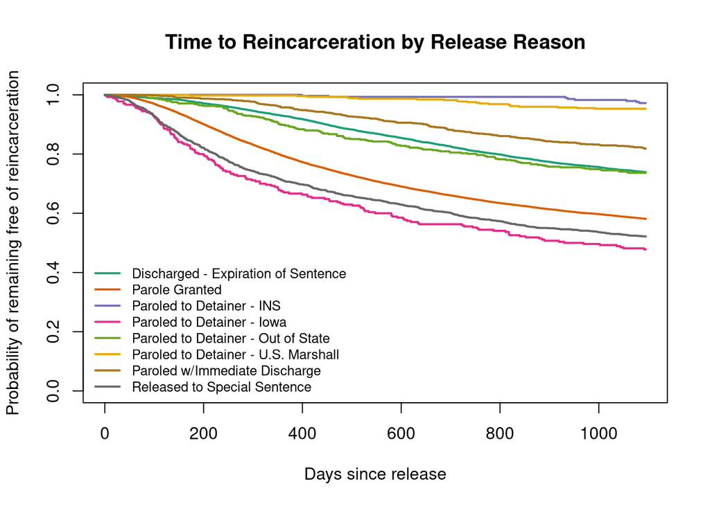

```r
km_exit_reason <- survfit(Surv(time_days, event) ~ exit_sup_reason, data = df)

colors <- brewer.pal(8, "Dark2")
labels <- sub("^[^=]+=", "", names(km_exit_reason$strata))

plot(km_exit_reason, col = colors, lwd = 2,
     xlab = "Days since release", ylab = "Probability of remaining free of reincarceration",
     xlim = c(0, 1095), ylim = c(0, 1),
     main = "Time to Reincarceration by Release Reason")
legend("bottomleft", bty = "n", lwd = 2,
       legend = labels,
       cex = 0.8,
       col = colors)
```

```r
survdiff(Surv(time_days, event) ~ exit_sup_reason, data = df)
```

```
Call:
survdiff(formula = Surv(time_days, event) ~ exit_sup_reason,
    data = df)

                                                        N Observed Expected
exit_sup_reason=Discharged - Expiration of Sentence  6958     1816   2849.9
exit_sup_reason=Parole Granted                      20551     8613   7252.6
exit_sup_reason=Paroled to Detainer - INS             288        8    132.0
exit_sup_reason=Paroled to Detainer - Iowa            270      141     82.8
exit_sup_reason=Paroled to Detainer - Out of State    482      127    193.8
exit_sup_reason=Paroled to Detainer - U.S. Marshall   446       21    202.6
exit_sup_reason=Paroled w/Immediate Discharge        1084      197    464.1
exit_sup_reason=Released to Special Sentence         1621      776    521.1
                                                    (O-E)^2/E (O-E)^2/V
exit_sup_reason=Discharged - Expiration of Sentence     375.1     496.5
exit_sup_reason=Parole Granted                          255.2     672.5
exit_sup_reason=Paroled to Detainer - INS               116.5     117.9
exit_sup_reason=Paroled to Detainer - Iowa               40.9      41.2
exit_sup_reason=Paroled to Detainer - Out of State       23.0      23.4
exit_sup_reason=Paroled to Detainer - U.S. Marshall     162.7     165.7
exit_sup_reason=Paroled w/Immediate Discharge           153.7     160.2
exit_sup_reason=Released to Special Sentence            124.6     130.5

 Chisq= 1255  on 7 degrees of freedom, p= <2e-16
```

```r
logrank_tests <- list(
  "Risk classification" = survdiff(
    Surv(time_days, event) ~ risk_ranking, data = df
  ),
  "Offense type" = survdiff(
    Surv(time_days, event) ~ exit_type, data = df
  ),
  "Sex" = survdiff(
    Surv(time_days, event) ~ sex, data = df
  ),
  "Release reason" = survdiff(
    Surv(time_days, event) ~ exit_sup_reason, data = df
  )
)

logrank_table <- imap_dfr(logrank_tests, function(test, comparison) {
  degrees_freedom <- sum(test$exp > 0) - 1

  tibble(
    comparison = comparison,
    chi_square = test$chisq,
    df = degrees_freedom,
    p_value = pchisq(
      test$chisq,
      df = degrees_freedom,
      lower.tail = FALSE
    )
  )
})

logrank_table |>
  mutate(
    chi_square = round(chi_square, 2),
    p_value = if_else(
      p_value < 0.001,
      "<0.001",
      sprintf("%.3f", p_value)
    )
  ) |>
  knitr::kable(
    col.names = c(
      "Comparison",
      "Chi-square",
      "Degrees of freedom",
      "Overall p-value"
    ),
    caption = "Log-Rank Tests",
    align = c("l", "r", "r", "r")
  )
```

Log-Rank Tests

| Comparison | Chi-square | Degrees of freedom | Overall p-value |
| --- | --- | --- | --- |
| Risk classification | 367.29 | 3 | <0.001 |
| Offense type | 527.04 | 4 | <0.001 |
| Sex | 98.53 | 1 | <0.001 |
| Release reason | 1254.57 | 7 | <0.001 |

```r
  # Log-rank tests indicated significant differences in time to reincarceration across risk classifications, offense types, sex, and release reasons (all p < 0.001)
```

```r
cox_model <- coxph(
  Surv(time_days, event) ~
    age_c +
    sex +
    risk_ranking +
    exit_type +
    exit_sup_reason,
  data = df,
  ties = "efron",
  x = TRUE
)

summary(cox_model)
```

```
Call:
coxph(formula = Surv(time_days, event) ~ age_c + sex + risk_ranking +
    exit_type + exit_sup_reason, data = df, ties = "efron", x = TRUE)

  n= 31700, number of events= 11699

                                                        coef exp(coef)
age_c                                              -0.014521  0.985584
sexMale                                             0.254196  1.289424
risk_rankingModerate                                0.165736  1.180261
risk_rankingHigh                                    0.415365  1.514924
risk_rankingNot Assessed                           -0.142416  0.867260
exit_typeOther                                      0.141515  1.152018
exit_typeProperty                                  -0.193171  0.824341
exit_typePublic Order                              -0.244079  0.783425
exit_typeViolent                                   -0.486150  0.614990
exit_sup_reasonParole Granted                       0.637046  1.890887
exit_sup_reasonParoled to Detainer - INS           -2.185311  0.112443
exit_sup_reasonParoled to Detainer - Iowa           0.954824  2.598214
exit_sup_reasonParoled to Detainer - Out of State   0.014889  1.015000
exit_sup_reasonParoled to Detainer - U.S. Marshall -1.879828  0.152616
exit_sup_reasonParoled w/Immediate Discharge       -0.329315  0.719416
exit_sup_reasonReleased to Special Sentence         1.041426  2.833255
                                                    se(coef)       z Pr(>|z|)
age_c                                               0.000976 -14.879  < 2e-16
sexMale                                             0.029928   8.494  < 2e-16
risk_rankingModerate                                0.030614   5.414 6.17e-08
risk_rankingHigh                                    0.023860  17.408  < 2e-16
risk_rankingNot Assessed                            0.057971  -2.457    0.014
exit_typeOther                                      0.034141   4.145 3.40e-05
exit_typeProperty                                   0.025257  -7.648 2.04e-14
exit_typePublic Order                               0.033477  -7.291 3.08e-13
exit_typeViolent                                    0.029008 -16.759  < 2e-16
exit_sup_reasonParole Granted                       0.026323  24.201  < 2e-16
exit_sup_reasonParoled to Detainer - INS            0.354448  -6.165 7.03e-10
exit_sup_reasonParoled to Detainer - Iowa           0.087527  10.909  < 2e-16
exit_sup_reasonParoled to Detainer - Out of State   0.091893   0.162    0.871
exit_sup_reasonParoled to Detainer - U.S. Marshall  0.219546  -8.562  < 2e-16
exit_sup_reasonParoled w/Immediate Discharge        0.075197  -4.379 1.19e-05
exit_sup_reasonReleased to Special Sentence         0.049062  21.227  < 2e-16
```

[output cut: 44 more lines]

```
exit_typeProperty                                    0.78453    0.8662
exit_typePublic Order                                0.73367    0.8366
exit_typeViolent                                     0.58100    0.6510
exit_sup_reasonParole Granted                        1.79581    1.9910
exit_sup_reasonParoled to Detainer - INS             0.05613    0.2252
exit_sup_reasonParoled to Detainer - Iowa            2.18863    3.0845
exit_sup_reasonParoled to Detainer - Out of State    0.84771    1.2153
exit_sup_reasonParoled to Detainer - U.S. Marshall   0.09925    0.2347
exit_sup_reasonParoled w/Immediate Discharge         0.62083    0.8337
exit_sup_reasonReleased to Special Sentence          2.57350    3.1192

Concordance= 0.638  (se = 0.002 )
Likelihood ratio test= 2777  on 16 df,   p=<2e-16
Wald test            = 2327  on 16 df,   p=<2e-16
Score (logrank) test = 2518  on 16 df,   p=<2e-16
```

```r
ph_check <- cox.zph(cox_model)

ph_check
```

```
                 chisq df       p
age_c             2.49  1 0.11453
sex               7.89  1 0.00496
risk_ranking     31.01  3 8.5e-07
exit_type        22.81  4 0.00014
exit_sup_reason 370.66  7 < 2e-16
GLOBAL          437.69 16 < 2e-16
```

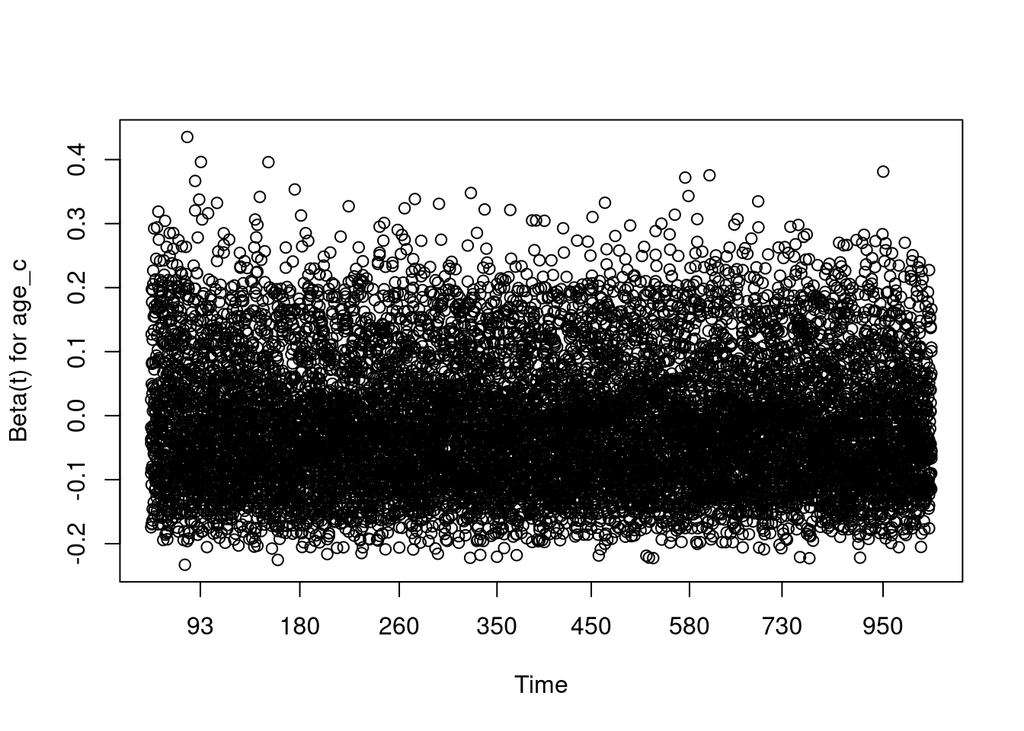

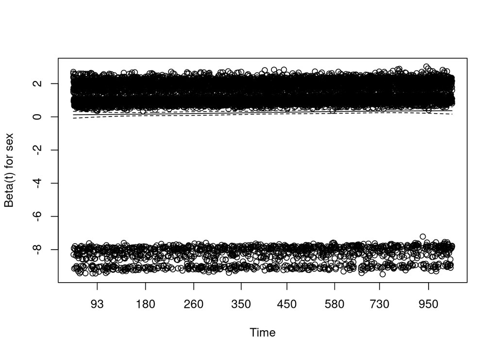

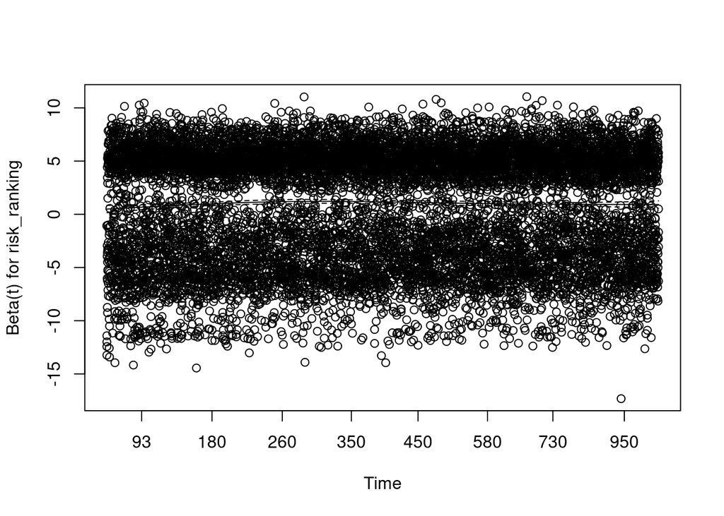

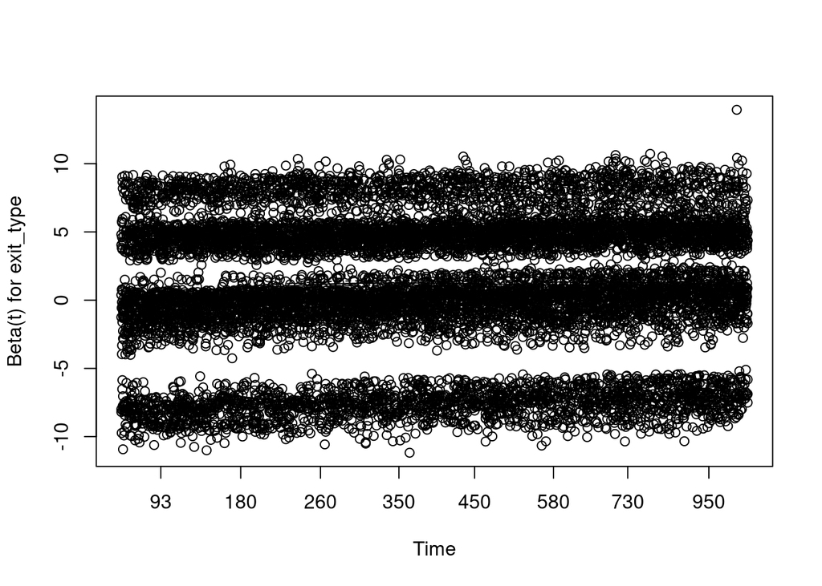

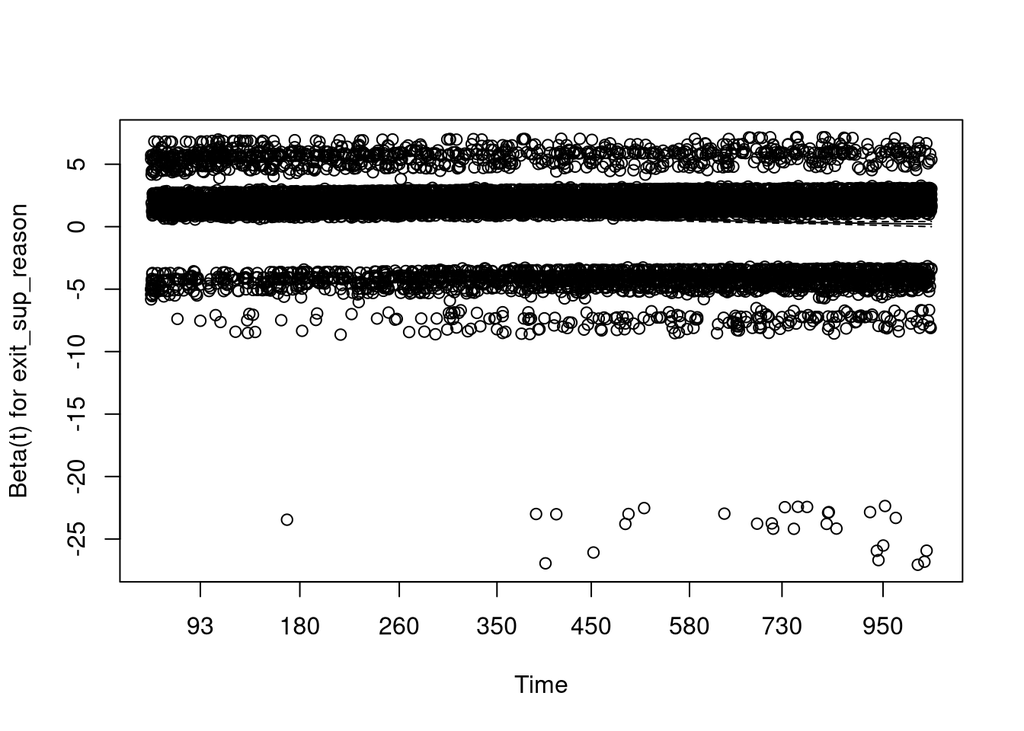

```r
plot(ph_check)
```

```r
# assumptions violated especially for release reason - stratify by release reason to allow each category its own baseline
cox_stratified <- coxph(
  Surv(time_days, event) ~
    age_c +
    sex +
    risk_ranking +
    exit_type +
    strata(exit_sup_reason),
  data = df,
  ties = "efron",
  x = TRUE
)

summary(cox_stratified)
```

```
Call:
coxph(formula = Surv(time_days, event) ~ age_c + sex + risk_ranking +
    exit_type + strata(exit_sup_reason), data = df, ties = "efron",
    x = TRUE)

  n= 31700, number of events= 11699

                               coef  exp(coef)   se(coef)       z Pr(>|z|)
age_c                    -0.0143612  0.9857415  0.0009763 -14.710  < 2e-16 ***
sexMale                   0.2544630  1.2897688  0.0299258   8.503  < 2e-16 ***
risk_rankingModerate      0.1646444  1.1789738  0.0306135   5.378 7.53e-08 ***
risk_rankingHigh          0.4125022  1.5105928  0.0238523  17.294  < 2e-16 ***
risk_rankingNot Assessed -0.1407038  0.8687466  0.0579044  -2.430   0.0151 *
exit_typeOther            0.1357150  1.1453554  0.0341499   3.974 7.06e-05 ***
exit_typeProperty        -0.1903409  0.8266773  0.0252569  -7.536 4.84e-14 ***
exit_typePublic Order    -0.2411218  0.7857459  0.0334785  -7.202 5.92e-13 ***
exit_typeViolent         -0.4828109  0.6170465  0.0290110 -16.642  < 2e-16 ***
---
Signif. codes:  0 '***' 0.001 '**' 0.01 '*' 0.05 '.' 0.1 ' ' 1

                         exp(coef) exp(-coef) lower .95 upper .95
age_c                       0.9857     1.0145    0.9839    0.9876
sexMale                     1.2898     0.7753    1.2163    1.3677
risk_rankingModerate        1.1790     0.8482    1.1103    1.2519
risk_rankingHigh            1.5106     0.6620    1.4416    1.5829
risk_rankingNot Assessed    0.8687     1.1511    0.7755    0.9732
exit_typeOther              1.1454     0.8731    1.0712    1.2246
exit_typeProperty           0.8267     1.2097    0.7868    0.8686
exit_typePublic Order       0.7857     1.2727    0.7358    0.8390
exit_typeViolent            0.6170     1.6206    0.5829    0.6531

Concordance= 0.592  (se = 0.003 )
Likelihood ratio test= 1245  on 9 df,   p=<2e-16
Wald test            = 1191  on 9 df,   p=<2e-16
Score (logrank) test = 1209  on 9 df,   p=<2e-16
```

```r
ph_stratified <- cox.zph(cox_stratified)
ph_stratified
```

```
              chisq df       p
age_c         0.443  1  0.5056
sex           7.148  1  0.0075
risk_ranking  8.631  3  0.0346
exit_type    50.489  4 2.9e-10
GLOBAL       67.151  9 5.5e-11
```

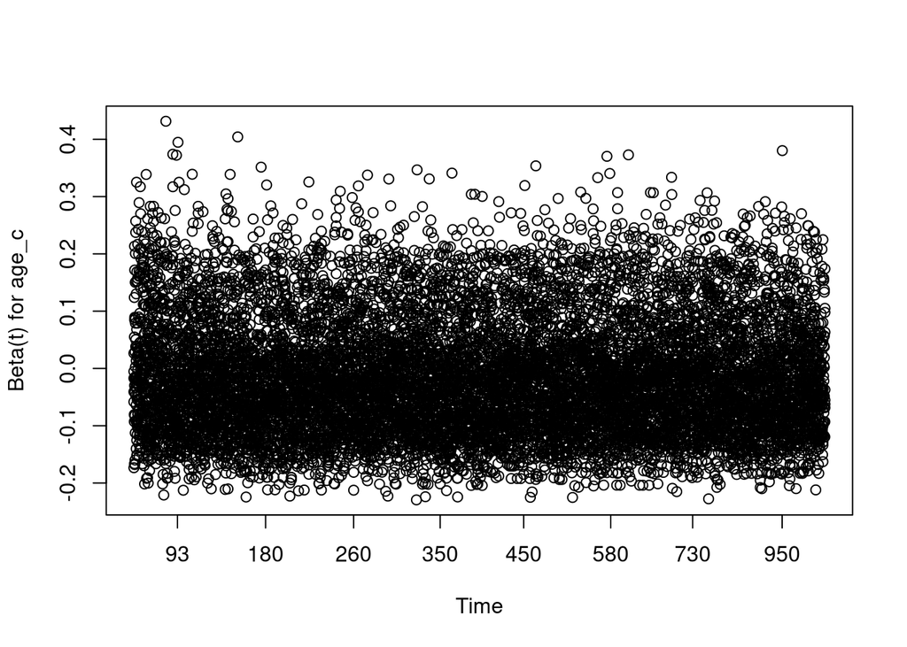

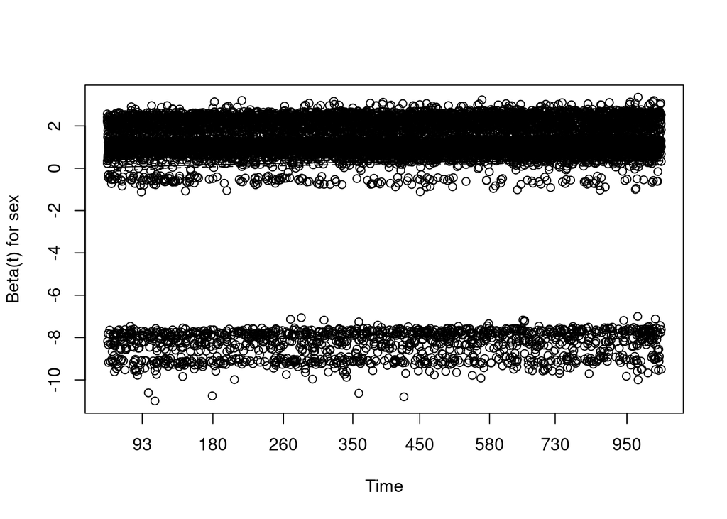

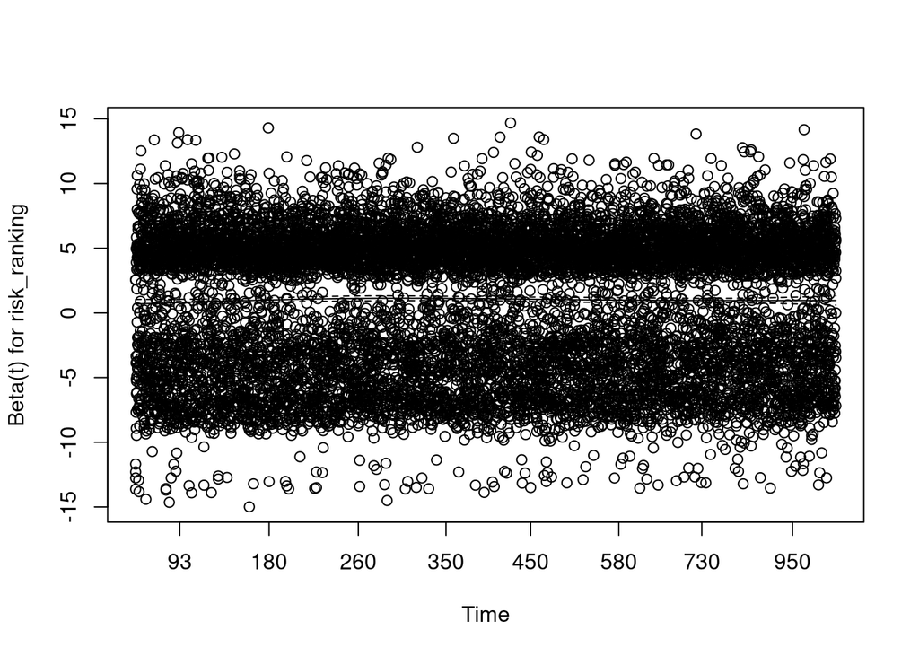

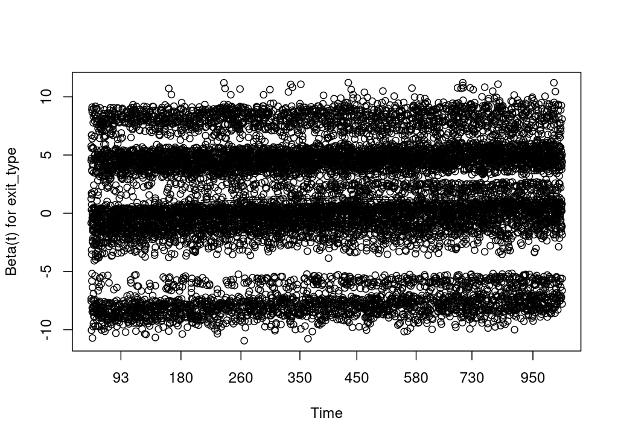

```r
plot(ph_stratified)
```

## References

Abadi, Alireza, Parvin Yavari, Monireh Dehghani-Arani, et al. 2014. “Cox Models Survival Analysis Based on Breast Cancer Treatments.” *Iranian Journal of Cancer Prevention* 7 (3): 124–29.

Bellera, Carine A., Gaëtan MacGrogan, Marc Debled, Christine Tunon de Lara, Véronique Brouste, and Simone Mathoulin-Pélissier. 2010. “Variables with Time-Varying Effects and the Cox Model: Some Statistical Concepts Illustrated with a Prognostic Factor Study in Breast Cancer.” *BMC Medical Research Methodology* 10 (1): 20. https://doi.org/10.1186/1471-2288-10-20.

Chau-Kuang, Chen. 2010. “Analyzing Student Learning Outcome: Stratified Cox Proportional Hazards Model.” *International Journal of Technology, Knowledge and Society* 6 (1): 167–78. https://www.proquest.com/scholarly-journals/analyzing-student-learning-outcome-stratified-cox/docview/2737145795/se-2.

Dirick, Lore, Gerda Claeskens, and Bart Baesens. 2017. “Time to Default in Credit Scoring Using Survival Analysis: A Benchmark Study.” *The Journal of the Operational Research Society* 68 (6): 652–65. https://www.proquest.com/scholarly-journals/time-default-credit-scoring-using-survival/docview/1892983862/se-2.

Hidayat, Yuyun, Sukono, Betty Subartini, Nida Khairunnisa, Aceng Sambas, and Titi Purwandari. 2022. “An Estimated Analysis of Willingness to Wait Time to Pay Rice Agricultural Insurance Premiums Using Cox’s Proportional Hazards Model.” *Mathematics* 10 (21): 3935. https://www.proquest.com/scholarly-journals/estimated-analysis-willingness-wait-time-pay-rice/docview/2734653773/se-2.

Iketle, Aretha M., Lizelle Fletcher, and Chen Ding-Geng. 2024. “Modified Cox Models: A Simulation Study on Different Survival Distributions, Censoring Rates, and Sample Sizes.” *Mathematics* 12 (18): 2903. https://www.proquest.com/scholarly-journals/modified-cox-models-simulation-study-on-different/docview/3110582165/se-2.

Ilari Kuitunen, Mikko M. Uimonen, Ville T. Ponkilainen. 2021. “Testing the Proportional Hazards Assumption in Cox Regression and Dealing with Possible Non-Proportionality in Total Joint Arthroplasty Research: Methodological Perspectives and Review.” *BMC Musculoskelet Disord* 22 (489). https://doi.org/10.1186/s12891-021-04379-2.

Ilari Kuitunen, Ville T. Ponkilainen, Atte Nikkilä. 2023. “Survival Analysis and Cox Proportional Hazards Model Reporting in Pediatric Leukemia Studies—a Systematic Review.” *SN Compr. Clin. Med* 5 (24). https://doi.org/10.1007/s42399-022-01367-y.

Lee, Seung Won. 2023. “Kaplan-Meier and Cox Proportional Hazards Regression in Survival Analysis: Statistical Standard and Guideline of Life Cycle Committee.” *Life Cycle* 3: e8. https://doi.org/10.54724/lc.2023.e8.

M. S. K, K. N. Reddy, J. Preetha, and S. Murugan. 2024. *Survival Analysis with Cox Proportional Hazards Model in Predicting Patient Outcomes*. 1155–61. https://doi.org/10.1109/ICESC60852.2024.10689732.

Soobramoney, Judah, Retius Chifurira, Knowledge Chinhamu, and Temesgen Zewotir. 2023. “Identifying the Key Hazards Behind Website Drop-Offs by Solving a Survival Problem.” *Applied Sciences* 13 (14): 8248. https://www.proquest.com/scholarly-journals/identifying-key-hazards-behind-website-drop-offs/docview/2842961357/se-2.

Wuryandari, Triastuti, Sri H. Kartiko, and Danardono. 2018. “The Cox Proportional Hazard Model on Duration of Birth Process.” *Journal of Physics: Conference Series* 1025 (1). https://www.proquest.com/scholarly-journals/cox-proportional-hazard-model-on-duration-birth/docview/2572271509/se-2.